# DATA605 Homework 11

Keith Colella

2023-11-12

```r
library(tidyverse)
```

# Assignment

Using the “cars” dataset in R, build a linear model for stopping distance as a function of speed and replicate the analysis of your textbook chapter 3 (visualization, quality evaluation of the model, and residual analysis).

# Response

We’ll start by loading in our dataset. Before we move to actual modeling, we’ll do some exploratory data analysis, plotting the distribution of each variable, along with a scatterplot examining the variables’ relationship.

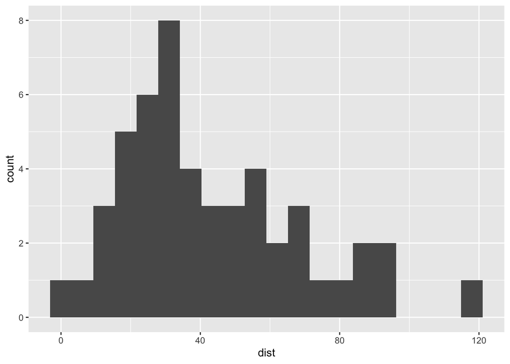

```r
data(cars)

cars %>%
  ggplot(aes(dist)) +
  geom_histogram(bins = 20)
```

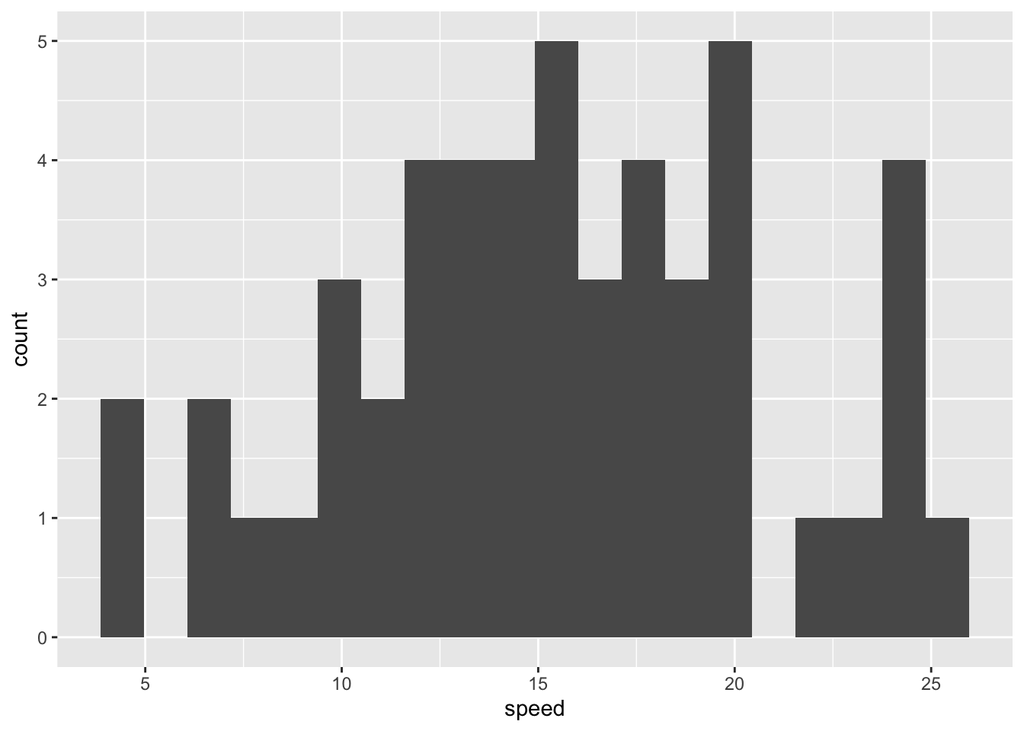

```r
cars %>%
  ggplot(aes(speed)) +
  geom_histogram(bins = 20)
```

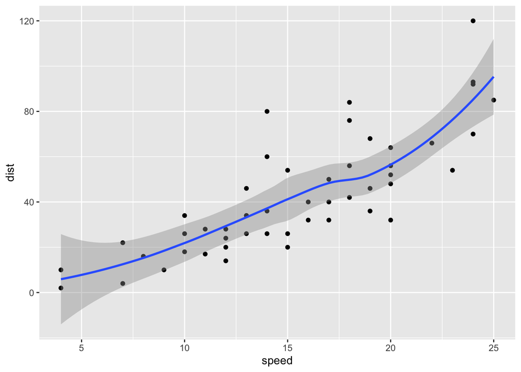

```r
cars %>%
  ggplot(aes(speed, dist)) +
  geom_point() +
  geom_smooth(formula = 'y ~ x', method = 'loess')
```

The two variables appear non-normal. This doesn’t necessary prove problematic for building a linear model. What’s more important is the presence of a linear relationship between the two. And our scatter plot (and LOESS line) seem to indicate a relatively clear linear relationship.

We can now move ahead with the actual model.

```r
model <- lm(dist ~ speed, data = cars)

summary(model)
```

```
##
## Call:
## lm(formula = dist ~ speed, data = cars)
##
## Residuals:
##     Min      1Q  Median      3Q     Max
## -29.069  -9.525  -2.272   9.215  43.201
##
## Coefficients:
##             Estimate Std. Error t value Pr(>|t|)
## (Intercept) -17.5791     6.7584  -2.601   0.0123 *
## speed         3.9324     0.4155   9.464 1.49e-12 ***
## ---
## Signif. codes:  0 '***' 0.001 '**' 0.01 '*' 0.05 '.' 0.1 ' ' 1
##
## Residual standard error: 15.38 on 48 degrees of freedom
## Multiple R-squared:  0.6511, Adjusted R-squared:  0.6438
## F-statistic: 89.57 on 1 and 48 DF,  p-value: 1.49e-12
```

Let’s examine how our predictions match up with actual values visually.

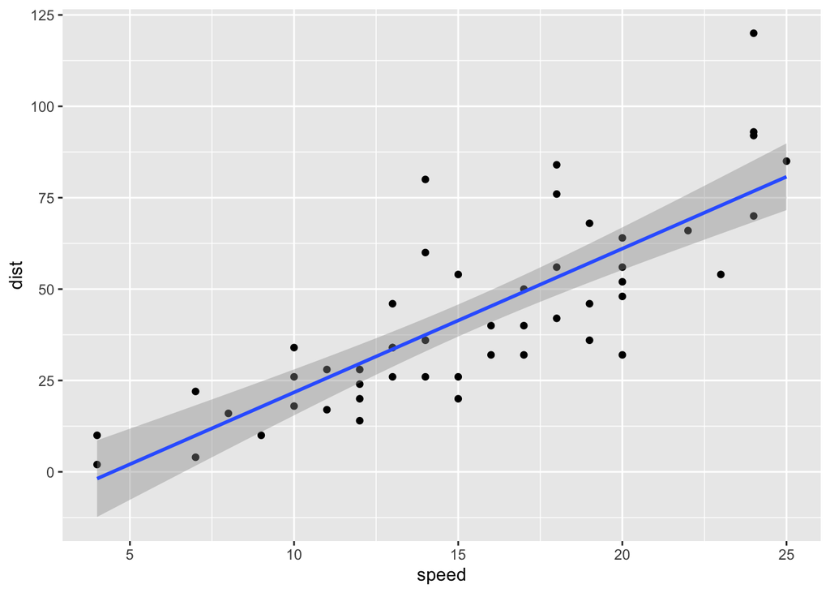

```r
cars %>%
  ggplot(aes(speed, dist)) +
  geom_point() +
  geom_smooth(formula = 'y ~ x', method = 'lm', se = TRUE)
```

Our predictions seem to match relatively well to actual values.

Finally, let’s examine the residuals for any potential problems.

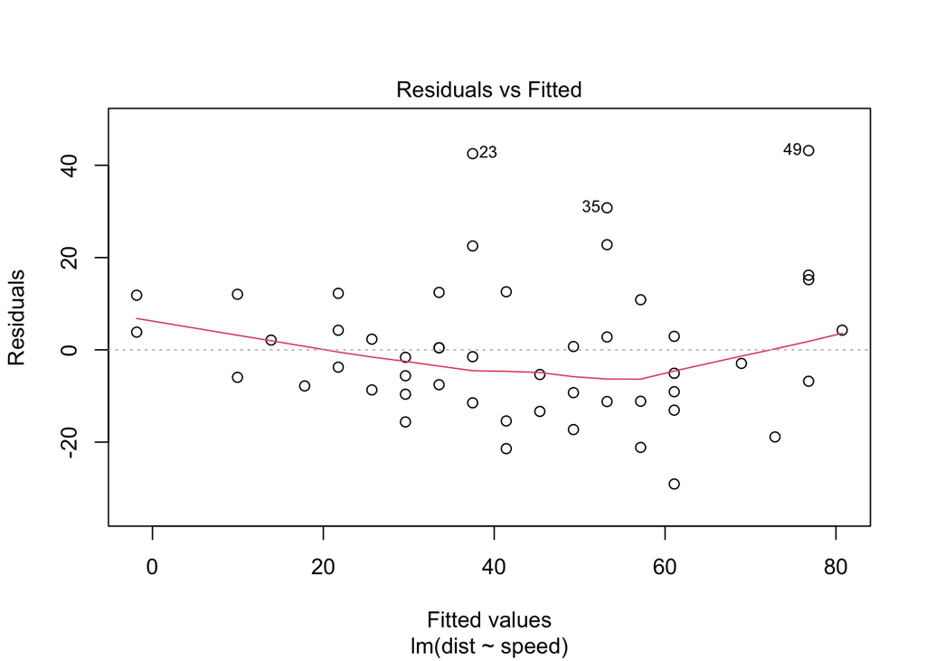

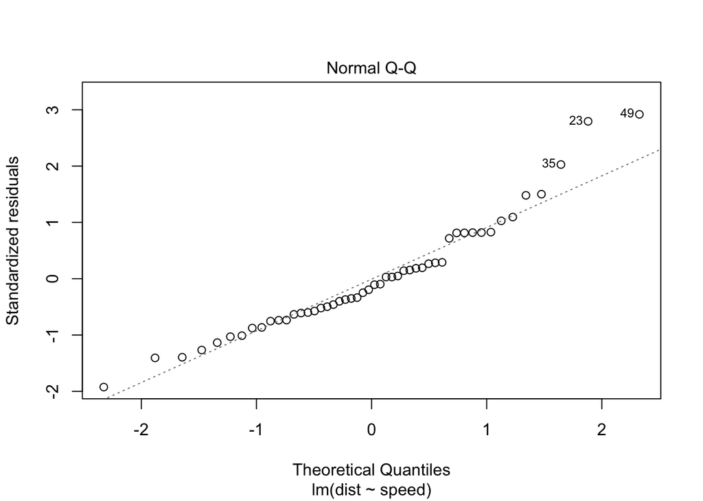

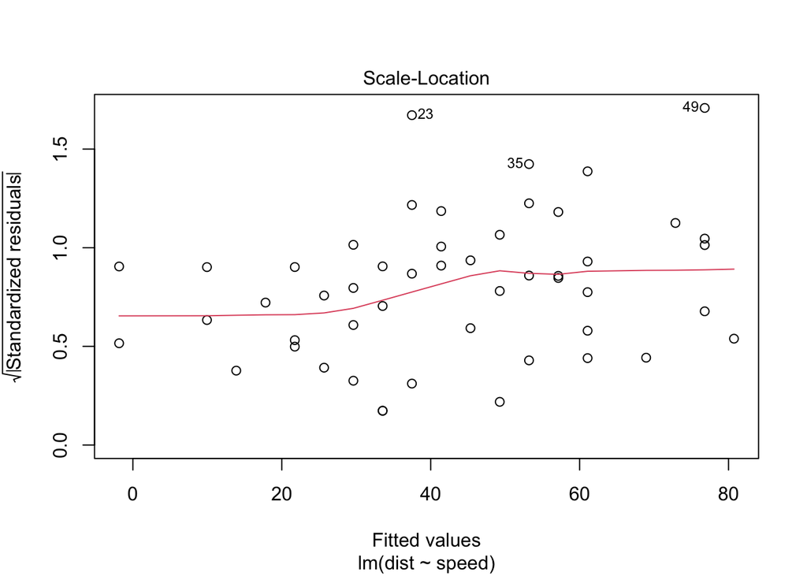

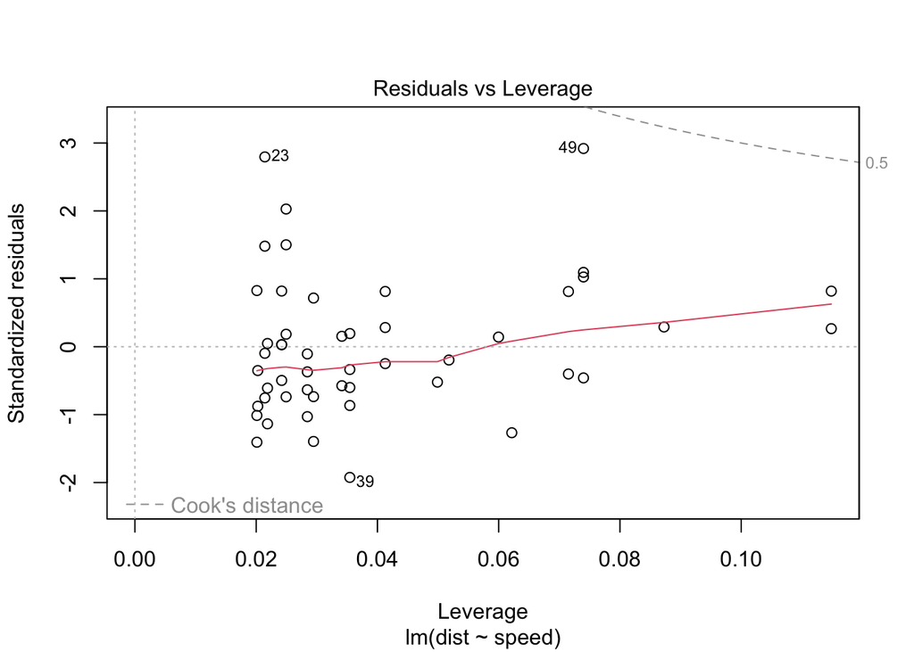

```r
plot(model)
```

Looking at our QQ plot, the residuals seem relatively normally distributed. There are some outliers in the right tail, but overall, the residuals sit along the normal diagonal.

Finally, our leverage plot indicates that, for the most part, single observations do not hold undue influence over parameter estimates. We see some tail values that have higher leverage, but nothing too concerning.

Overall, our model seems to provide a good fit and key regression assumptions hold!